# Pràctica 2 - Mètodes de Classificació

Axel Romero

25/10/2020

```r
library(tidyverse)
library(ISLR)
library(MASS)
library(lmtest)
library(gridExtra)
library(ggpubr)
library(knitr)
library(caret)
library(klaR)
library(car)
```

# 1 Exercici 1

Tenim el model de regressió logística
$$log\left(\frac{P(Y = Sí)}{1 - P(Y = Sí)}\right) = \beta_0 + \beta_1 X_1 + \beta_2 X_2$$
On

- $Y$: Obté una nota de A? (Sí, No)
- $X_1$: hores estudiades.
- $X_2$: Nota obtinguda. (GPA)

Ajustem el model i obtenim les següents estimacions dels coeficients: $\hat\beta_0 = -6$, $\hat\beta_1 = 0.05$ i $\hat\beta_2 = 1$.

**A.)**
Hem de calcular la probabilitat que un estudiant obtingui una nota de A si $X_1 = 40$ i $X_2 = 3.5$.
$$P(Y = Sí) = \frac{e^{\beta_0 + \beta_1 X_1 + \beta_2 X_2}}{1 + e^{\beta_0 + \beta_1 X_1 + \beta_2 X_2}} = \frac{e^{-6 + 0.05 \times 40 + 1 \times 3.5}}{1 + e^{-6 + 0.05 \times 40 + 1 \times 3.5}} = 0.3775407$$

**B.)**
Hem de determinar un valor de $X_1$ tal que, mantenint el valor de $X_2$, la probabilitat d’obtenir una nota de A és del 50%.
$$P(Y = Sí) = 0.5 \rightarrow log\left(\frac{P(Y = Sí)}{1 - P(Y = Sí)}\right) = 0$$
Ara podem trobar el valor de $X_1$ que satisfaci l’equació:
$$0 = \beta_0 + \beta_1 X_1 + \beta_2 X_2 = -6 + 0.05 \times X_1 + 3.5 \rightarrow \boxed{X_1 = 50}$$
Si l’alumne estudia durant 50 hores i té un GPA de 3.5, la probabilitat d’obtenir una nota de A serà del 50%.

# 2 Exercici 2

Tenim la següent funció logística amb un únic predictor:
$$P(Y = 1) = \frac{e^{\beta_0 + \beta_1 X}}{1 + e^{\beta_0 + \beta_1 X}}$$
Generem un vector $x$ que contingui 100 valors entre -10 i 10.

```r
x <- seq(-10, 10, length.out = 100)
length(x)
```

```
## [1] 100
```

Generem un vector $y$ que contingui la funció logística aplicada a $x$ amb $\beta_0 = 0$ i $\beta_1 = 1$.

```r
y <- exp(x)/(1 + exp(x))
```

Fem la representació gràfica de la corba.

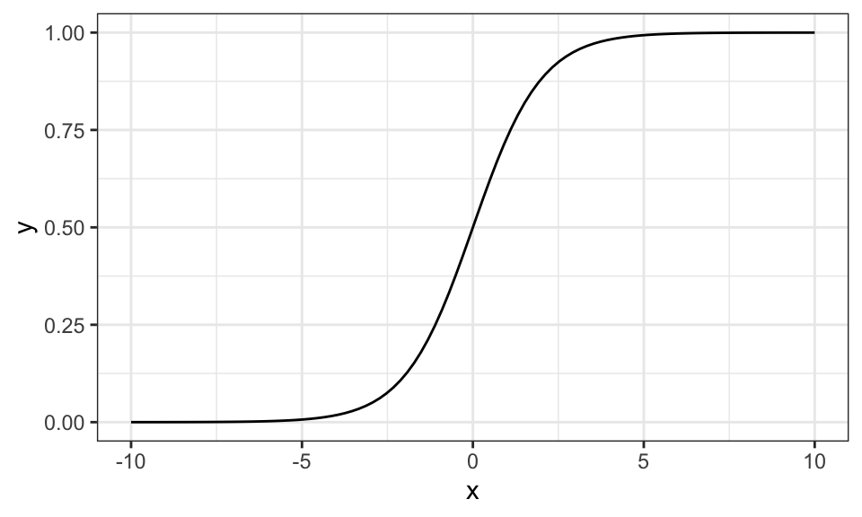

```r
ggplot(data = data.frame(x = x, y = y), aes(x = x, y = y)) +
  geom_line() + theme_bw()
```

Ara fem una funció que produeixi un gràfic per a qualsevol valor de $\beta_0$ i $\beta_1$.

```r
logistic_graf <- function(betas){
  # x --> vector de dades x
  # betas --> vector amb els coeficients.
  x <- seq(-10, 10, length.out = 100)
  y <- exp(betas[1] + betas[2] * x) / (1 + exp(betas[1] + betas[2] * x))

  plot(x, y, type = 'l')
}
```

```r
for(b0 in c(0.2, -2.6, -6)){
  par(mfrow = c(3, 2))
  for(b1 in c(1, -1.5, -5, 0.5, 0.1)){
    logistic_graf(c(b0, b1))
    title(main = paste0('beta0 = ',b0, ' i beta1 = ', b1))
  }
  par(mfrow = c(1, 1))
}
```

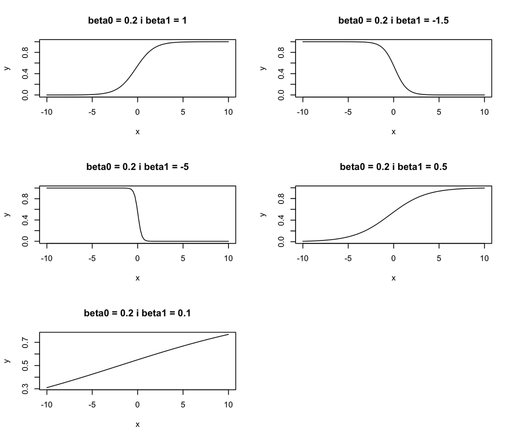

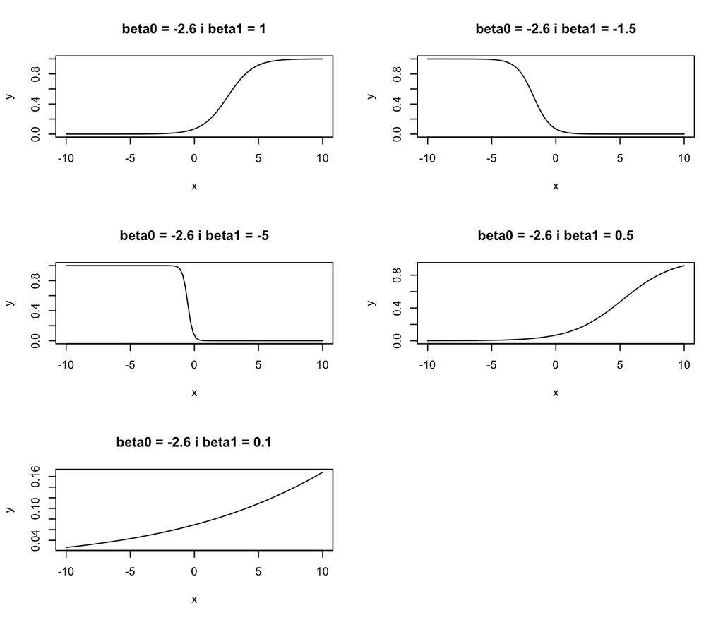

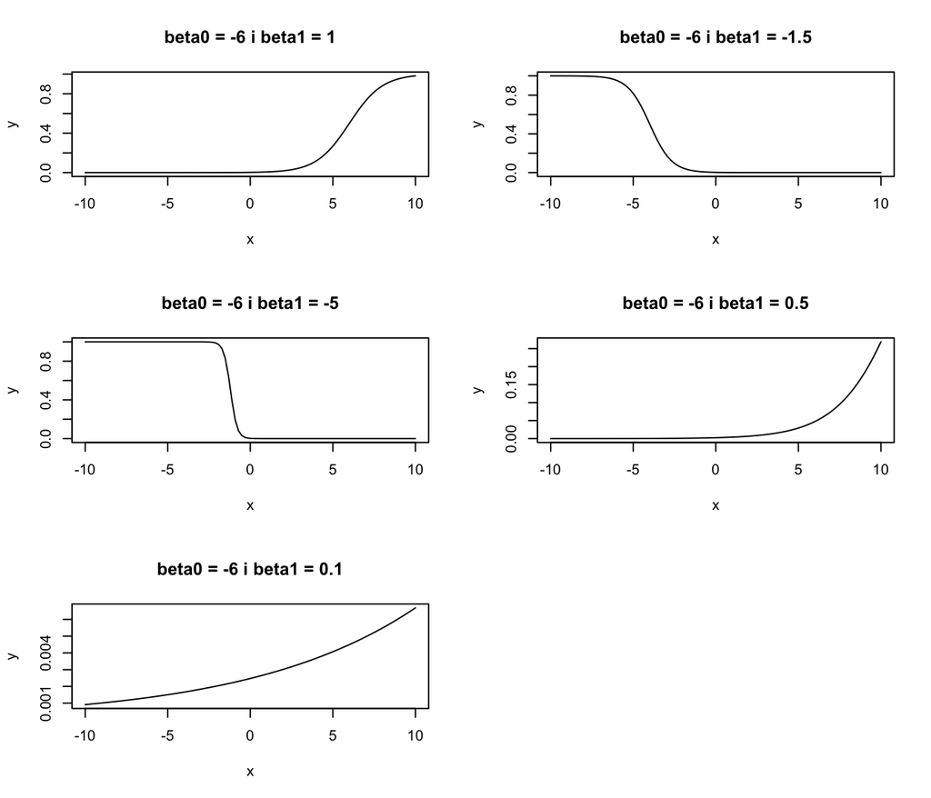

# 3 Exercici 3

La base de dades `birthwt` de la llibreria MASS conté informació de 189 naixements d’un hospital dels Estats Units. Conté diferents variables i té l’objectiu d’investigar els factors de risc associats a un baix pes del nadó (menys de 2500gr).  
Les variables d’interès són:

- `low`: factor que indica si el nadó pesa menys de 2.5kg.
- `age`: edat de la mare, en anys.
- `lwt`: pes de la mare en lliura en l’últim període menstrual.

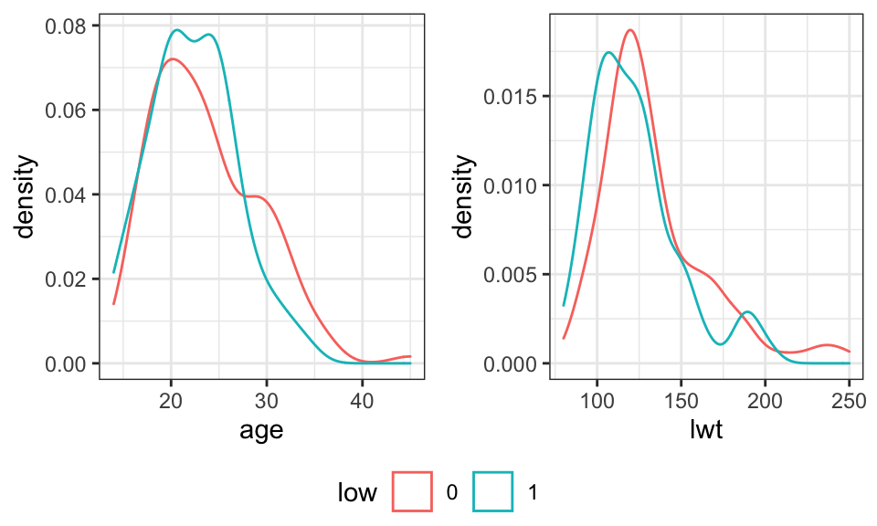

Ajustem un model amb totes les variables d’interès.

```r
mod1 <- glm(low ~ age + lwt,
            data = birthwt,
            family = binomial)
summary(mod1)$coefficients
```

```
##                Estimate  Std. Error   z value   Pr(>|z|)
## (Intercept)  1.74877349 0.997096536  1.753866 0.07945351
## age         -0.03978793 0.032287314 -1.232309 0.21783386
## lwt         -0.01277541 0.006211224 -2.056827 0.03970285
```

Veiem que la variable `age` no és significativa, ja que té un p-valor $0.2178 > \alpha = 0.05$. Per aquesta variable no podem rebutjar que sigui igual a 0, i per tant no té un efecte en la variable resposta.  
Mirem el model sense aquesta variable.

```r
mod2 <- glm(low ~ lwt,
            data = birthwt,
            family = binomial)
summary(mod2)$coefficients
```

```
##                Estimate  Std. Error   z value   Pr(>|z|)
## (Intercept)  0.99831432 0.785290874  1.271267 0.20363370
## lwt         -0.01405826 0.006169588 -2.278639 0.02268856
```

La variable `lwt` segueix sent significativa, és a dir sí que afecta en la variable resposta. Després, podem veure que l’intercept no dóna significatiu.  
Per comparar els dos models podem fer el Likelihood Ratio Test.

```r
lrtest(mod1, mod2)
```

```
## Likelihood ratio test
##
## Model 1: low ~ age + lwt
## Model 2: low ~ lwt
##   #Df  LogLik Df  Chisq Pr(>Chisq)
## 1   3 -113.56
## 2   2 -114.34 -1 1.5673     0.2106
```

El test no dóna significatiu així que el model més complex (que té la variable `age`) no és millor que el més simple. Ens quedem amb el model més simple, pel principi de parsimònia, perquè afegir la variable `age` no aporta una millora.

# 4 Exercici 4

Tenim un estudi de casos i controls per avaluar un factor de risc associat a una malaltia. Els resultats estan recollits en la següent taula:

|  | Casos | Controls |
| --- | --- | --- |
| Presència factor de risc | 43 | 8 |
| Absència factor de risc | 57 | 92 |
|  | 100 | 100 |

La (Odds - Ratio) és
$$\widehat{OR} = \frac{\widehat{odds}(Cas|Presència)}{\widehat{odds}(Cas|Absència)}$$
On
$$\widehat{odds}(Cas|Presència) = \frac{\hat P(Cas|Presèncua)}{\hat P(Control|Presència)} = \frac{43/51}{8/51} = \frac{43}{8}$$
i
$$\widehat{odds}(Cas|Absència) = \frac{\hat P(Cas|Absència)}{\hat P(Control|Absència)} = \frac{57/149}{92/149} = \frac{57}{92}$$
Així que els Odds Ratio queden
$$\widehat{OR} = \frac{43/8}{57/92} = 8.6754$$
Això vol dir que tenir present el factor de risc incrementa els odds de ser cas 8.6754 vegades. Es diu que aquest factor és de risc perquè el OR > 1. En cas contrari, de OR < 1, el factor seria protector.

Ara ajustem un model de regressió logística per veure si la presència del factor de risc té algun efecte en ser cas o no.

```r
taula <- matrix(c(43, 8, 57, 92),
                nrow = 2,
                byrow = T)
grup <- factor(c('Presencia', 'Absencia'))
grup <- relevel(grup, ref = 'Absencia')
mod3 <- glm(taula ~ grup,
            family = binomial)
summary(mod3)$coefficients
```

```
##                 Estimate Std. Error   z value     Pr(>|z|)
## (Intercept)   -0.4787373  0.1685628 -2.840112 4.509768e-03
## grupPresencia  2.1604959  0.4203204  5.140117 2.745675e-07
```

Veiem que els dos coeficients són estadísticament significatius, ja que tenen un p-valor $< \alpha$. Això ens diu que el fet de tenir la presència del factor de risc si té un efecte. L’estimació dels coeficients són $\hat \beta_0 = -0.4787$ i $\hat \beta_1 = 2.1605$.

Amb el model de regressió logística es pot calcular els Odds Ratio, $\widehat{OR} = e^{\hat \beta_1} = e^{2.1605} = 8.6754$. La interpretació és la mateixa que abans, la quantitat de vegades que augmenta la probabilitat de ser cas tenint la presència del factor de risc.

# 5 Exercici 5

Tenim la base de dades `Boston`, que conté informació de diferents suburbis de Boston. Hem de crear un model capaç de predir si el suburbi té una taxa de criminalitat per sobre o per sota de la mitjana. Creem aquesta variable dicotòmica en la base de dades.

```r
Boston2 <- Boston %>%
  mutate(
    crim_mean = as.factor(ifelse(crim >= mean(crim), 'Yes', 'No'))
  ) %>%
  dplyr::select(-crim)
```

Primer mirem com ajusta un model de regressió logística per predir si el suburbi té una taxa de criminalitat superior a la mitjana.

```r
mod_log <- glm(crim_mean ~.,
               data = Boston2,
               family = binomial)
summary(mod_log)$coefficients
```

```
##                 Estimate   Std. Error       z value   Pr(>|z|)
## (Intercept) 17.441033207 1.262398e+04  0.0013815792 0.99889766
## zn          -0.307889615 6.630164e+02 -0.0004643770 0.99962948
## indus        0.932895458 8.937081e+02  0.0010438481 0.99916713
## chas        -3.268219886 3.530749e+00 -0.9256450346 0.35463048
## nox          1.510765835 1.325047e+01  0.1140160300 0.90922509
## rm          -1.701904094 1.366638e+00 -1.2453221496 0.21301336
## age          0.193870197 8.635548e-02  2.2450248100 0.02476654
## dis          0.007818954 1.895258e+00  0.0041255364 0.99670831
## rad          1.985327751 5.238067e+02  0.0037901916 0.99697587
## tax         -0.005463369 2.181536e+01 -0.0002504367 0.99980018
## ptratio     -3.931179047 1.122545e+03 -0.0035020246 0.99720579
## black        0.001358420 8.966621e-03  0.1514974314 0.87958334
## lstat        0.030701781 2.133452e-01  0.1439066118 0.88557421
## medv        -0.017127720 1.603052e-01 -0.1068444299 0.91491240
```

```r
AIC(mod_log)
```

```
## [1] 49.11535
```

Veiem que en aquest model pràcticament totes les variables no són significatives. Mirem com és la capacitat predictiva d’aquest model.

```r
preds_log <- as.factor(ifelse(fitted(mod_log) >= .5, 'Yes', 'No'))
confusionMatrix(preds_log, Boston2$crim_mean)
```

```
## Confusion Matrix and Statistics
##
##           Reference
## Prediction  No Yes
##        No  376   2
##        Yes   2 126
##
##                Accuracy : 0.9921
##                  95% CI : (0.9799, 0.9978)
##     No Information Rate : 0.747
##     P-Value [Acc > NIR] : <2e-16
##
##                   Kappa : 0.9791
##
##  Mcnemar's Test P-Value : 1
##
##             Sensitivity : 0.9947
##             Specificity : 0.9844
##          Pos Pred Value : 0.9947
##          Neg Pred Value : 0.9844
##              Prevalence : 0.7470
##          Detection Rate : 0.7431
##    Detection Prevalence : 0.7470
##       Balanced Accuracy : 0.9895
##
##        'Positive' Class : No
##
```

Es pot observar que la precisió és de 99.21%, molt alta, i per tant l’error d’entrenament és 0.79%. El model, en tenir tantes variables no significatives, es pot simplificar. El problema és que s’han d’anar traient les variables una a una per veure si canvia la significació de la resta.  
Per fer-ho més ràpidament utilitzem un mètode de selecció automàtica amb direcció cap darrere.

```r
mod_log2 <- step(glm(crim_mean ~.,
               data = Boston2,
               family = binomial), direction = 'backward')
```

```r
summary(mod_log2)$coefficients
```

```
##                Estimate Std. Error   z value     Pr(>|z|)
## (Intercept) -11.4593276 5.32385929 -2.152447 3.136213e-02
## rm           -2.7700138 1.08064344 -2.563300 1.036823e-02
## age           0.1987139 0.06563827  3.027410 2.466594e-03
## rad           0.7494566 0.18047240  4.152749 3.285049e-05
```

```r
AIC(mod_log2)
```

```
## [1] 31.54742
```

Aquest és el model resultat, només té tres variables i són significatives. A més, veiem que el AIC en aquest model és inferior que en l’anterior i per tant podem dir que és millor.  
Mirem ara si la capacitat predictiva s’ha vist afectada.

```r
preds_log2 <- as.factor(ifelse(fitted(mod_log2) >= 0.5, 'Yes', 'No'))
confusionMatrix(preds_log2, Boston2$crim_mean)
```

```
## Confusion Matrix and Statistics
##
##           Reference
## Prediction  No Yes
##        No  376   2
##        Yes   2 126
##
##                Accuracy : 0.9921
##                  95% CI : (0.9799, 0.9978)
##     No Information Rate : 0.747
##     P-Value [Acc > NIR] : <2e-16
##
##                   Kappa : 0.9791
##
##  Mcnemar's Test P-Value : 1
##
##             Sensitivity : 0.9947
##             Specificity : 0.9844
##          Pos Pred Value : 0.9947
##          Neg Pred Value : 0.9844
##              Prevalence : 0.7470
##          Detection Rate : 0.7431
##    Detection Prevalence : 0.7470
##       Balanced Accuracy : 0.9895
##
##        'Positive' Class : No
##
```

Es pot observar com la precisió segueix sent la mateixa, prediu igual de bé tenint moltes menys variables.

Ara provem un mètode de classificació diferent, el LDA.

```r
mod_lda <- lda(crim_mean ~.,
               data = Boston2)
mod_lda
```

```
## Call:
## lda(crim_mean ~ ., data = Boston2)
##
## Prior probabilities of groups:
##        No       Yes
## 0.7470356 0.2529644
##
## Group means:
##           zn     indus       chas       nox       rm      age      dis
## No  15.21164  8.774947 0.07407407 0.5135283 6.381593 60.93360 4.398107
## Yes  0.00000 18.111563 0.05468750 0.6762656 5.998305 91.14062 2.014120
##           rad      tax  ptratio    black    lstat     medv
## No   4.706349 321.6481 17.87937 380.6835 10.52458 24.67751
## Yes 23.851562 663.9453 20.15703 285.7711 18.93875 16.19922
##
## Coefficients of linear discriminants:
##                   LD1
## zn       0.0122071037
## indus   -0.0023636274
## chas    -0.3465336797
## nox      0.7787120098
## rm      -0.1311420276
## age      0.0036664029
## dis     -0.0589644691
## rad      0.3830702632
## tax      0.0001023832
## ptratio  0.0500026976
## black   -0.0009676037
## lstat    0.0153197742
## medv     0.0029734654
```

Ara que tenim el model ajustat mirem la precisió per poder-ho comparar amb el model de regressió logística.

```r
preds_lda <- predict(object = mod_lda,
                     newdata = Boston2[,-ncol(Boston2)])
confusionMatrix(preds_lda$class, Boston2$crim_mean)
```

```
## Confusion Matrix and Statistics
##
##           Reference
## Prediction  No Yes
##        No  373   1
##        Yes   5 127
##
##                Accuracy : 0.9881
##                  95% CI : (0.9744, 0.9956)
##     No Information Rate : 0.747
##     P-Value [Acc > NIR] : <2e-16
##
##                   Kappa : 0.9689
##
##  Mcnemar's Test P-Value : 0.2207
##
##             Sensitivity : 0.9868
##             Specificity : 0.9922
##          Pos Pred Value : 0.9973
##          Neg Pred Value : 0.9621
##              Prevalence : 0.7470
##          Detection Rate : 0.7372
##    Detection Prevalence : 0.7391
##       Balanced Accuracy : 0.9895
##
##        'Positive' Class : No
##
```

Es pot observar que la precisió ara és del 98,81%, és a dir un error d’entrenament de 1.19%. Segueix sent un valor d’error molt petit, però té una mica més d’error que el model de regressió logística.

En aquest cas ens quedem amb el model de regressió logística, ja que dóna una precisió una mica més elevada i perquè és un model més simple i fàcil d’interpretar. A més, amb el model logístic, en tenir coeficients, podem veure la relació de cada variable amb la resposta binària i entendre, en cada situació, perquè s’ha assignat l’observació a un cert grup.

# 6 Exercici 6

```r
data("Weekly")
```

## 6.1 A.)

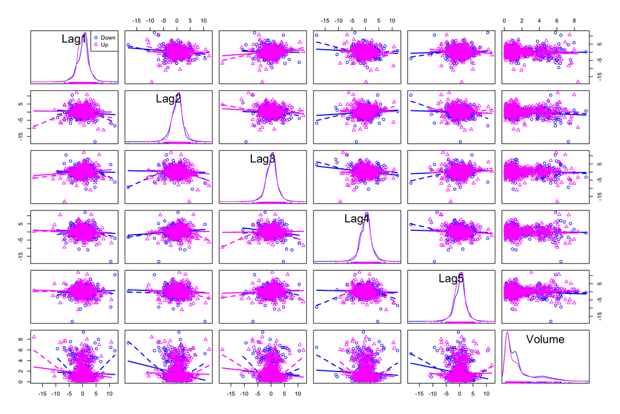

```r
scatterplotMatrix(~ Lag1 + Lag2 + Lag3 + Lag4 + Lag5 + Volume|Direction, data = Weekly)
```

Es pot observar que els dos grups de la variable `Direction` (Up i Down) pràcticament no es diferencien en cap de les variables i parelles de variables. Això pot indicar que el model no tindrà una capacitat predictiva molt bona, ja que no hi ha cap variable capaç de separar els grups.

## 6.2 B.)

Ajustem un model de regressió logística.

```r
log_week <- glm(Direction ~ Lag1 + Lag2 + Lag3 + Lag4 + Lag5 + Volume,
                data = Weekly,
                family = binomial)
summary(log_week)$coefficients
```

```
##                Estimate Std. Error    z value    Pr(>|z|)
## (Intercept)  0.26686414 0.08592961  3.1056134 0.001898848
## Lag1        -0.04126894 0.02641026 -1.5626099 0.118144368
## Lag2         0.05844168 0.02686499  2.1753839 0.029601361
## Lag3        -0.01606114 0.02666299 -0.6023760 0.546923890
## Lag4        -0.02779021 0.02646332 -1.0501409 0.293653342
## Lag5        -0.01447206 0.02638478 -0.5485006 0.583348244
## Volume      -0.02274153 0.03689812 -0.6163330 0.537674762
```

La gran majoria de variables no són significatives, l’única és `Lag2`. Veiem que l’intercept també és significatiu.

## 6.3 C.)

Ara considerem un model de regressió logística on l’única variable explicativa és `Lag2` i a més dividim la base de dades en train i test.

```r
train.week <- Weekly %>%
  filter(
    Year <= 2008
  )
test.week <- Weekly %>%
  filter(
    Year > 2008
  )
```

```r
mod.week <- glm(Direction ~ Lag2,
                data = train.week,
                family = binomial)
summary(mod.week)$coefficients
```

```
##               Estimate Std. Error  z value   Pr(>|z|)
## (Intercept) 0.20325743 0.06428036 3.162046 0.00156665
## Lag2        0.05809527 0.02870446 2.023911 0.04297934
```

```r
preds.wee <- predict(mod.week, newdata = test.week)
preds.wee.c <- as.factor(ifelse(preds.wee >= 0.5, 'Up', 'Down'))
confusionMatrix(preds.wee.c, test.week$Direction)
```

```
## Confusion Matrix and Statistics
##
##           Reference
## Prediction Down Up
##       Down   41 56
##       Up      2  5
##
##                Accuracy : 0.4423
##                  95% CI : (0.345, 0.543)
##     No Information Rate : 0.5865
##     P-Value [Acc > NIR] : 0.9989
##
##                   Kappa : 0.0299
##
##  Mcnemar's Test P-Value : 3.421e-12
##
##             Sensitivity : 0.95349
##             Specificity : 0.08197
##          Pos Pred Value : 0.42268
##          Neg Pred Value : 0.71429
##              Prevalence : 0.41346
##          Detection Rate : 0.39423
##    Detection Prevalence : 0.93269
##       Balanced Accuracy : 0.51773
##
##        'Positive' Class : Down
##
```

La precisió és bastant baixa, del 44.23%, és a dir que té un error d’entrenament de 55.77%. Tal i com sabia comentat a l’apartat A.), la qualitat del model és baixa.

## 6.4 D.)

Ara provem amb un LDA.

```r
lda.week <- lda(Direction ~ Lag2,
                data = train.week)
lda.week
```

```
## Call:
## lda(Direction ~ Lag2, data = train.week)
##
## Prior probabilities of groups:
##      Down        Up
## 0.4477157 0.5522843
##
## Group means:
##             Lag2
## Down -0.03568254
## Up    0.26036581
##
## Coefficients of linear discriminants:
##            LD1
## Lag2 0.4414162
```

```r
preds.wee.lda <- predict(lda.week, newdata = test.week)
confusionMatrix(preds.wee.lda$class, test.week$Direction)
```

```
## Confusion Matrix and Statistics
##
##           Reference
## Prediction Down Up
##       Down    9  5
##       Up     34 56
##
##                Accuracy : 0.625
##                  95% CI : (0.5247, 0.718)
##     No Information Rate : 0.5865
##     P-Value [Acc > NIR] : 0.2439
##
##                   Kappa : 0.1414
##
##  Mcnemar's Test P-Value : 7.34e-06
##
##             Sensitivity : 0.20930
##             Specificity : 0.91803
##          Pos Pred Value : 0.64286
##          Neg Pred Value : 0.62222
##              Prevalence : 0.41346
##          Detection Rate : 0.08654
##    Detection Prevalence : 0.13462
##       Balanced Accuracy : 0.56367
##
##        'Positive' Class : Down
##
```

Veiem que ara la precisió és del 62.5%, bastant més elevada que en el cas de la regressió logística, però segueix sent una precisió baixa.

## 6.5 E.)

Ara utilitzem el mètode QDA.

```r
qda.week <- qda(Direction ~ Lag2,
                data = train.week)
qda.week
```

```
## Call:
## qda(Direction ~ Lag2, data = train.week)
##
## Prior probabilities of groups:
##      Down        Up
## 0.4477157 0.5522843
##
## Group means:
##             Lag2
## Down -0.03568254
## Up    0.26036581
```

```r
preds.week.qda <- predict(qda.week, newdata = test.week)
confusionMatrix(preds.week.qda$class, test.week$Direction)
```

```
## Confusion Matrix and Statistics
##
##           Reference
## Prediction Down Up
##       Down    0  0
##       Up     43 61
##
##                Accuracy : 0.5865
##                  95% CI : (0.4858, 0.6823)
##     No Information Rate : 0.5865
##     P-Value [Acc > NIR] : 0.5419
##
##                   Kappa : 0
##
##  Mcnemar's Test P-Value : 1.504e-10
##
##             Sensitivity : 0.0000
##             Specificity : 1.0000
##          Pos Pred Value :    NaN
##          Neg Pred Value : 0.5865
##              Prevalence : 0.4135
##          Detection Rate : 0.0000
##    Detection Prevalence : 0.0000
##       Balanced Accuracy : 0.5000
##
##        'Positive' Class : Down
##
```

Ara la precisió és del 58.65%, superior a la de la regressió logística i inferior a la del LDA. És una precisió aproximadament del 50%, és a dir, és un model bastant dolent.

## 6.6 F.)

| Models | Precisió |
| --- | --- |
| Log | 0.4423 |
| LDA | 0.6250 |
| QDA | 0.5865 |

El mètode LDA és el que dóna un error d’aprenentatge inferior i una precisió superior. Aquest és el millor dels tres, però no és del tot bo, té poca precisió.

## 6.7 G.)

Per veure si hi ha una altra combinació de variables predictores, mirem un mètode de selecció de variables automàtica.

```r
mod.weeek.2 <- step(glm(Direction ~ Lag1 + Lag2 + Lag3 + Lag4 + Lag5 + Volume,
                        data = train.week,
                        family = binomial), direction = 'backward')
```

```r
summary(mod.weeek.2)$coefficients
```

```
##                Estimate Std. Error   z value    Pr(>|z|)
## (Intercept)  0.21108631 0.06456472  3.269376 0.001077851
## Lag1        -0.05420833 0.02886051 -1.878288 0.060341823
## Lag2         0.05384325 0.02904693  1.853664 0.063787285
```

```r
preds.week.2 <- predict(mod.weeek.2, newdata = test.week)
preds.week.2.c <-  as.factor(ifelse(preds.week.2 >= 0.5, 'Up', 'Down'))
confusionMatrix(preds.week.2.c, test.week$Direction)
```

```
## Confusion Matrix and Statistics
##
##           Reference
## Prediction Down Up
##       Down   39 56
##       Up      4  5
##
##                Accuracy : 0.4231
##                  95% CI : (0.3268, 0.5239)
##     No Information Rate : 0.5865
##     P-Value [Acc > NIR] : 0.9997
##
##                   Kappa : -0.0094
##
##  Mcnemar's Test P-Value : 4.577e-11
##
##             Sensitivity : 0.90698
##             Specificity : 0.08197
##          Pos Pred Value : 0.41053
##          Neg Pred Value : 0.55556
##              Prevalence : 0.41346
##          Detection Rate : 0.37500
##    Detection Prevalence : 0.91346
##       Balanced Accuracy : 0.49447
##
##        'Positive' Class : Down
##
```

Tornem a obtenir una precisió molt baixa i seguim tenint millors resultats amb el mètode LDA.  
El model final seria el LDA però s’ha de tenir en compte que és bastant dolent, té un error elevat.

# 7 Exercici 7

```r
data("Auto")
```

## 7.1 A.)

Creem una variable binària que conté un 1 si el valor de `mpg` està per sobre de la mediana, i un 0 si el valor està per sota. Aquesta serà la nostra variable resposta de l’estudi.

```r
auto.2 <- Auto %>%
  mutate(
    mpg01 = as.factor(ifelse(mpg >= median(mpg), 1, 0))
  )
```

## 7.2 B.)

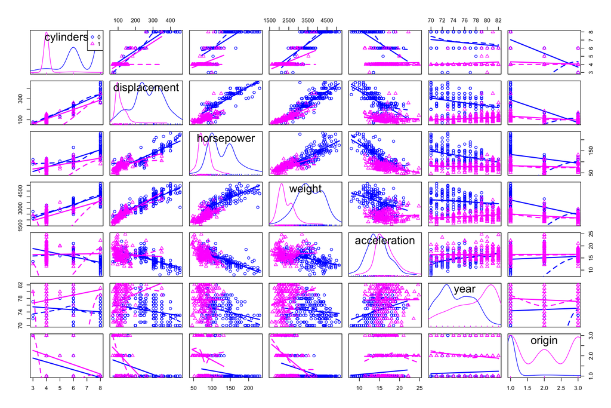

```r
scatterplotMatrix(~.|mpg01, data = auto.2[,-c(1, 9)])
```

En aquest cas si es poden veure variables i combinacions de variables que separen bastant bé els grups de la variable `mpg01`. Per exemple la distribució de variables com `displacement` o `weight` és bastant diferent en els dos grups. També és interessant observar que en molts gràfics bivariants, una línia seria una bona separació, com per exemple en el cas `displacement ~ horsepower`, així que un bon mètode podria ser el LDA.

## 7.3 C.)

Dividim les dades en train i test, on train conté el 75% de les dades i test la resta.

```r
smp_size <- floor(0.75 *  nrow(auto.2))
set.seed(123)
train_ind <- sample(seq_len(nrow(auto.2)), size = smp_size)
auto.train <- auto.2[train_ind,]
auto.test <- auto.2[-train_ind,]
```

## 7.4 D.)

Ajustem un LDA amb les variables que veiem interessants de l’apartat B.

```r
auto.lda <- lda(mpg01 ~ displacement + horsepower + weight + year + origin,
                data = auto.train)
auto.lda
```

```
## Call:
## lda(mpg01 ~ displacement + horsepower + weight + year + origin,
##     data = auto.train)
##
## Prior probabilities of groups:
##         0         1
## 0.4931973 0.5068027
##
## Group means:
##   displacement horsepower   weight     year   origin
## 0     273.4207  130.03448 3623.538 74.36552 1.151724
## 1     114.2752   78.16107 2318.987 77.71141 1.966443
##
## Coefficients of linear discriminants:
##                       LD1
## displacement -0.006484018
## horsepower    0.009323075
## weight       -0.001236437
## year          0.129897991
## origin        0.164234172
```

```r
auto.lda.preds <- predict(auto.lda, newdata = auto.test)
confusionMatrix(auto.lda.preds$class, auto.test$mpg01)
```

```
## Confusion Matrix and Statistics
##
##           Reference
## Prediction  0  1
##          0 42  3
##          1  9 44
##
##                Accuracy : 0.8776
##                  95% CI : (0.7959, 0.9351)
##     No Information Rate : 0.5204
##     P-Value [Acc > NIR] : 5.688e-14
##
##                   Kappa : 0.7559
##
##  Mcnemar's Test P-Value : 0.1489
##
##             Sensitivity : 0.8235
##             Specificity : 0.9362
##          Pos Pred Value : 0.9333
##          Neg Pred Value : 0.8302
##              Prevalence : 0.5204
##          Detection Rate : 0.4286
##    Detection Prevalence : 0.4592
##       Balanced Accuracy : 0.8798
##
##        'Positive' Class : 0
##
```

Amb el LDA obtenim una precisió del 87.76%, que és bastant elevada i està força bé. A més aquesta precisió és a una base de dades diferent de la que s’ha entrenat el model.

## 7.5 E.)

```r
auto.qda <- qda(mpg01 ~ displacement + horsepower + weight + year + origin,
                data = auto.train)
auto.qda
```

```
## Call:
## qda(mpg01 ~ displacement + horsepower + weight + year + origin,
##     data = auto.train)
##
## Prior probabilities of groups:
##         0         1
## 0.4931973 0.5068027
##
## Group means:
##   displacement horsepower   weight     year   origin
## 0     273.4207  130.03448 3623.538 74.36552 1.151724
## 1     114.2752   78.16107 2318.987 77.71141 1.966443
```

```r
auto.qda.preds <- predict(auto.qda, newdata = auto.test)
confusionMatrix(auto.qda.preds$class, auto.test$mpg01)
```

```
## Confusion Matrix and Statistics
##
##           Reference
## Prediction  0  1
##          0 45  3
##          1  6 44
##
##                Accuracy : 0.9082
##                  95% CI : (0.8328, 0.9571)
##     No Information Rate : 0.5204
##     P-Value [Acc > NIR] : <2e-16
##
##                   Kappa : 0.8165
##
##  Mcnemar's Test P-Value : 0.505
##
##             Sensitivity : 0.8824
##             Specificity : 0.9362
##          Pos Pred Value : 0.9375
##          Neg Pred Value : 0.8800
##              Prevalence : 0.5204
##          Detection Rate : 0.4592
##    Detection Prevalence : 0.4898
##       Balanced Accuracy : 0.9093
##
##        'Positive' Class : 0
##
```

Ara el QDA. La precisió en aquest cas és superior, de 90.82% que és força elevada. Sembla que el mètode QDA funciona millor que el LDA.

## 7.6 F.)

Ara apliquem un model de regressió logística.

```r
auto.log <- glm(mpg01 ~ displacement + horsepower + weight + year + origin,
                data = auto.train,
                family = binomial)
summary(auto.log)
```

```
##
## Call:
## glm(formula = mpg01 ~ displacement + horsepower + weight + year +
##     origin, family = binomial, data = auto.train)
##
## Deviance Residuals:
##      Min        1Q    Median        3Q       Max
## -2.34017  -0.07168   0.01798   0.17038   2.44603
##
## Coefficients:
##                Estimate Std. Error z value Pr(>|z|)
## (Intercept)  -18.964383   5.962291  -3.181 0.001469 **
## displacement  -0.002072   0.009432  -0.220 0.826127
## horsepower    -0.053401   0.020268  -2.635 0.008420 **
## weight        -0.004443   0.001212  -3.667 0.000246 ***
## year           0.474685   0.092801   5.115 3.14e-07 ***
## origin         0.457242   0.429392   1.065 0.286940
## ---
## Signif. codes:  0 '***' 0.001 '**' 0.01 '*' 0.05 '.' 0.1 ' ' 1
##
## (Dispersion parameter for binomial family taken to be 1)
##
##     Null deviance: 407.52  on 293  degrees of freedom
## Residual deviance: 103.80  on 288  degrees of freedom
## AIC: 115.8
##
## Number of Fisher Scoring iterations: 8
```

Es pot observar que hi ha un parell de variables que no són significatives, `displacement` i `origin`. La resta sí que són significatives i per tant afecten a la variable resposta.

```r
auto.log.preds <- predict(auto.log, newdata = auto.test)
auto.log.preds.c <- as.factor(ifelse(auto.log.preds >=  .5, 1, 0))
confusionMatrix(auto.log.preds.c, auto.test$mpg01)
```

```
## Confusion Matrix and Statistics
##
##           Reference
## Prediction  0  1
##          0 47  8
##          1  4 39
##
##                Accuracy : 0.8776
##                  95% CI : (0.7959, 0.9351)
##     No Information Rate : 0.5204
##     P-Value [Acc > NIR] : 5.688e-14
##
##                   Kappa : 0.7539
##
##  Mcnemar's Test P-Value : 0.3865
##
##             Sensitivity : 0.9216
##             Specificity : 0.8298
##          Pos Pred Value : 0.8545
##          Neg Pred Value : 0.9070
##              Prevalence : 0.5204
##          Detection Rate : 0.4796
##    Detection Prevalence : 0.5612
##       Balanced Accuracy : 0.8757
##
##        'Positive' Class : 0
##
```

En aquest cas, la precisió és del 87.76%. És una precisió elevada i semblant a la del LDA.

En conclusió, el model que ha obtingut millors resultats en la base de dades de test, sent entrenat per la base de dades train, és el QDA, té una precisió d’aproximadament un 3% més elevada.